# Support-vector machine

Michał Stawikowski

17 - 04 - 2019

```r
knitr::opts_chunk$set(cache=TRUE)
```

# 1 Wstęp

W tym raporcie spróbuję przyjrzeć się bliżej algorytmowi `SVM`, który wykorzystam do przeprowadzenia regresji na dwóch zbiorach danych. Wybiorę najbardziej istotne hipermparametry regresora i postaram się dostroić je do regresji na zbiorach danych `Apartments` z pakietu `DALEX` oraz `White_wine`. Zbadam jak algorytm zmienia się wraz z modyfikacją hiperparametrów, a także porównam go z modelem drzewiastym.

# 2 Normalizacja danych

Z [raportu](http://pyml.sourceforge.net/doc/howto.pdf) wynika, że normalizacja danych może mieć wpływ na działanie alogrytmu `SVM`. Porównam wyniki algorytmu dla surowych danych `Apartments`, a także dla wyskalowanych i wystandaryzowanych odpowiedników.

Wyniki bez skalowania.

```r
#Apartments

models_task <- makeRegrTask(id = "apart", data = apartments, target = "m2.price")
models_svm_lrn <- makeLearner("regr.ksvm",scaled=F)
regr_svm <- mlr::train(models_svm_lrn, models_task)

performance(predict(regr_svm, newdata = test),
            measures = list(mse, rmse, mae, rsq))
```

```
##          mse         rmse          mae          rsq
## 7.851524e+05 8.860883e+02 6.893771e+02 3.163778e-02
```

`Apartments`

```r
models_task2T <- makeRegrTask(id = "wine", data = train_set_wine, target = "V1")
models_svm_lrn2T <- makeLearner("regr.ksvm",scaled=F)
regr_svm2T <- mlr::train(models_svm_lrn2T, models_task2T)

performance(predict(regr_svm2T, newdata = test_set),
            measures = list(mse, rmse, mae, rsq))
```

```
##        mse       rmse        mae        rsq
## 0.69517198 0.83376974 0.62363865 0.07465379
```

`White_wine`

Teraz zobaczymy jak wpłynie na wyniki skalowania danych dla zbioru `Apartments`.

```r
# Wyniki ze skalowaniem

## Skalowanie
#Apartments

models_task <- makeRegrTask(id = "apart", data = apartments, target = "m2.price")
models_svm_lrn <- makeLearner("regr.ksvm",scaled=T)
regr_svm <- mlr::train(models_svm_lrn, models_task)

performance(predict(regr_svm, newdata = test),
            measures = list(mse, rmse, mae, rsq))
```

```
##          mse         rmse          mae          rsq
## 2.791237e+04 1.670700e+02 1.310051e+02 9.655745e-01
```

Dla drugiego zbioru

```r
models_task2T <- makeRegrTask(id = "wine", data = train_set_wine, target = "V1")
models_svm_lrn2T <- makeLearner("regr.ksvm",scaled=T)
regr_svm2T <- mlr::train(models_svm_lrn2T, models_task2T)

performance(predict(regr_svm2T, newdata = test_set),
            measures = list(mse, rmse, mae, rsq))
```

```
##       mse      rmse       mae       rsq
## 0.1931288 0.4394642 0.3089916 0.7429255
```

Jak widzimy skalowanie wnosi dość sporą poprawę, co potwierdza wnisoki z wyżej wymienionego raportu.

# 3 Strojenie hiperparametrów

W tej części raportu będę starał się znaleźć jak najlepsze parametry algorytmu dla naszych problemów.

## 3.1 Wybór jądra

Pierwszym krokiem będzie wybór funkcji jądra. Porównamy trzy rodzaje jąder:

- `Jądro Gaussowskie`
- `Jądro Wielomianowe`
- `Jądro Liniowe`

Według wcześniej wspomnianego artykułu najlepiej powinien poradzić sobie model z jądrem gaussowskim, a najgorzej powinno wypaść najprostsze jądro liniowe. Sprawdźmy to.

```r
## Gauss

models_task <- makeRegrTask(id = "apart", data = apartments, target = "m2.price")
models_svm_lrn <- makeLearner("regr.ksvm")
regr_svm <- mlr::train(models_svm_lrn, models_task)

performance(predict(regr_svm, newdata = test),
            measures = list(mse, rmse, mae, rsq))
```

```
##          mse         rmse          mae          rsq
## 2.830285e+04 1.682345e+02 1.315711e+02 9.650929e-01
```

Jądro gaussowskie.

```r
## Liniowe

models_task <- makeRegrTask(id = "apart", data = apartments, target = "m2.price")
models_svm_lrn <- makeLearner("regr.ksvm", kernel = "vanilladot")
regr_svm <- mlr::train(models_svm_lrn, models_task)
performance(predict(regr_svm, newdata = test),
            measures = list(mse, rmse, mae, rsq))
```

```
##          mse         rmse          mae          rsq
## 9.093029e+04 3.015465e+02 2.283710e+02 8.878518e-01
```

Jądro liniowe

```r
## Wielomianowe

models_task <- makeRegrTask(id = "apart", data = apartments, target = "m2.price")
models_svm_lrn <- makeLearner("regr.ksvm", kernel = "polydot")
regr_svm <- mlr::train(models_svm_lrn, models_task)
performance(predict(regr_svm, newdata = test),
            measures = list(mse, rmse, mae, rsq))
```

```
##          mse         rmse          mae          rsq
## 9.092507e+04 3.015378e+02 2.283845e+02 8.878582e-01
```

Oraz jądro wielomianowe.

Tak jak przewidywaliśmy najlepiej poradziło sobie jądro gaussowskie, które jest domyślnie ustawione w implementacji `SVM`, z której będę korzystał w dalszej części raportu - `ksvm`.

## 3.2 Strojenie najważniejszych parametrów

W artykule możemy przeczytać, że najistotniejszymi parametrami są `C` - “cost of constraints violation” i `Sigma` - “inverse kernel width” dla jądra Gaussowskiego. Pierwszy odpowiada za kary nakładane za błędną klasyfikacje i “błędy marginesów”, drugi odpowiada za sposób w jaki algorytm wyznacza granicę dzielącą dwie klasy. Do wyszukania korzystnych parametrów posłużymy się funkcją losowego szukania parametrów - `random search`.

```r
# Strojenie hiperparametrów metodą random search



num_ps = makeParamSet(
  makeNumericParam("C", lower = -10, upper = 10, trafo = function(x) 10^x),
  makeNumericParam("sigma", lower = -10, upper = 10, trafo = function(x) 10^x)
)

ctrl = makeTuneControlRandom(maxit = 200L)
rdesc = makeResampleDesc("CV", iters = 3L)

# Apartaments

resA = tuneParams("regr.ksvm", task = models_task, resampling = rdesc,
                  par.set = num_ps, control = ctrl)

# Wine

resW =  tuneParams("regr.ksvm", task = models_task2, resampling = rdesc,
                   par.set = num_ps, control = ctrl)
```

```r
print(resA)
```

```
## Tune result:
## Op. pars: C=3.2e+03; sigma=0.000734
## mse.test.mean=20764.0113520
```

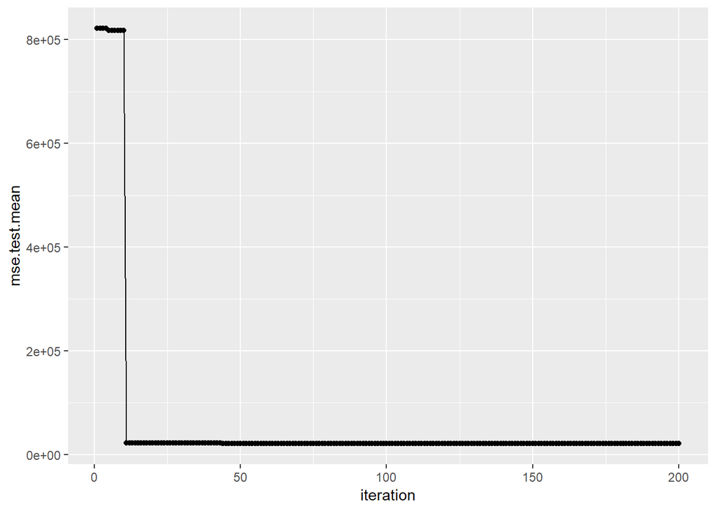

```r
dataA = generateHyperParsEffectData(resA)
plotHyperParsEffect(dataA, x = "iteration", y = "mse.test.mean",
                    plot.type = "line")
```

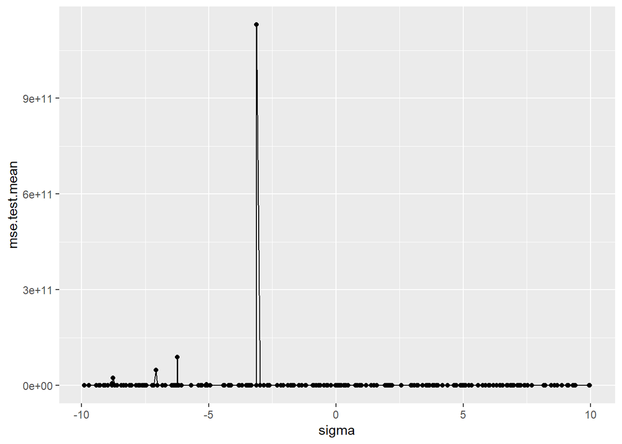

```r
plotHyperParsEffect(dataA, x = "sigma", y = "mse.test.mean",
                    plot.type = "line")
```

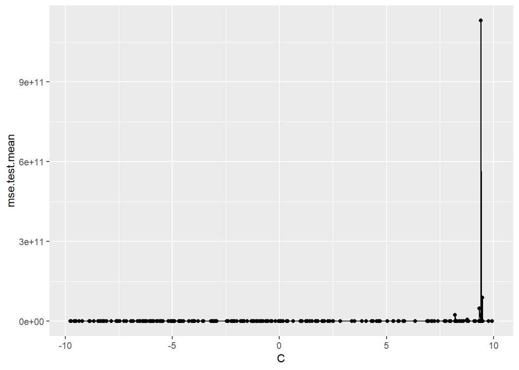

```r
plotHyperParsEffect(dataA, x = "C", y = "mse.test.mean",
                    plot.type = "line")
```

Zbiór `Apartments`.

```r
print(resW)
```

```
## Tune result:
## Op. pars: C=1.43e+03; sigma=0.00016
## mse.test.mean=0.2181123
```

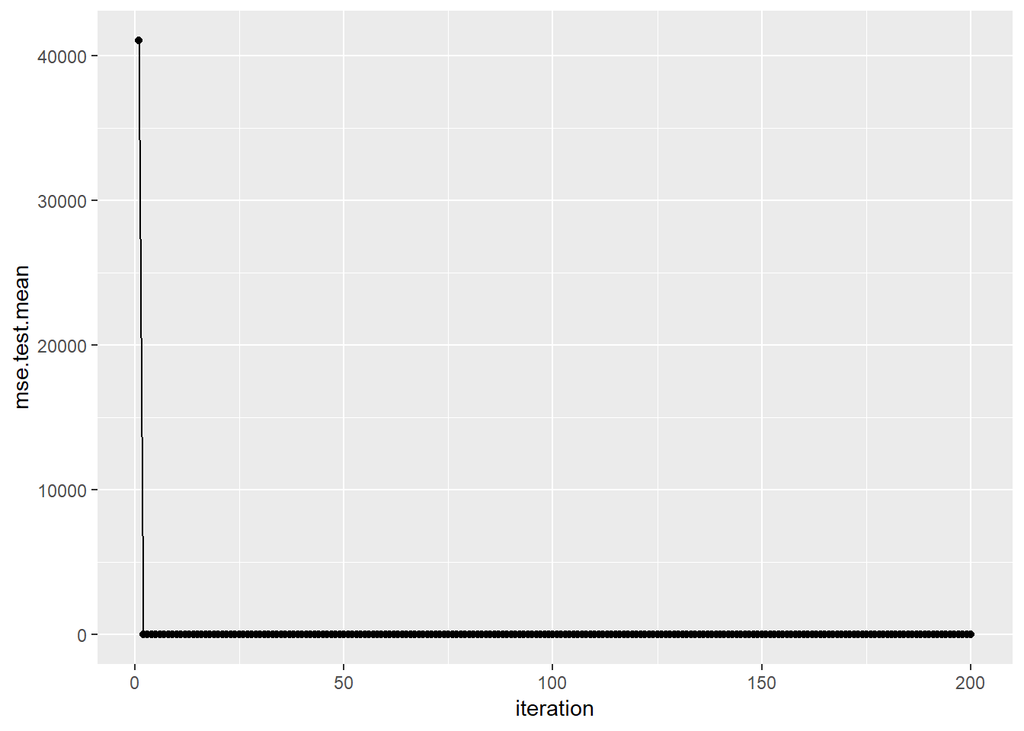

```r
dataW = generateHyperParsEffectData(resW)
plotHyperParsEffect(dataW, x = "iteration", y = "mse.test.mean",
                    plot.type = "line")
```

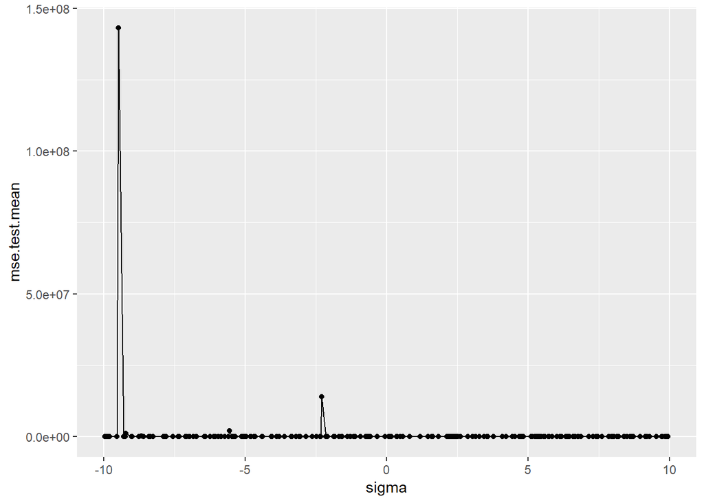

```r
plotHyperParsEffect(dataW, x = "sigma", y = "mse.test.mean",
                    plot.type = "line")
```

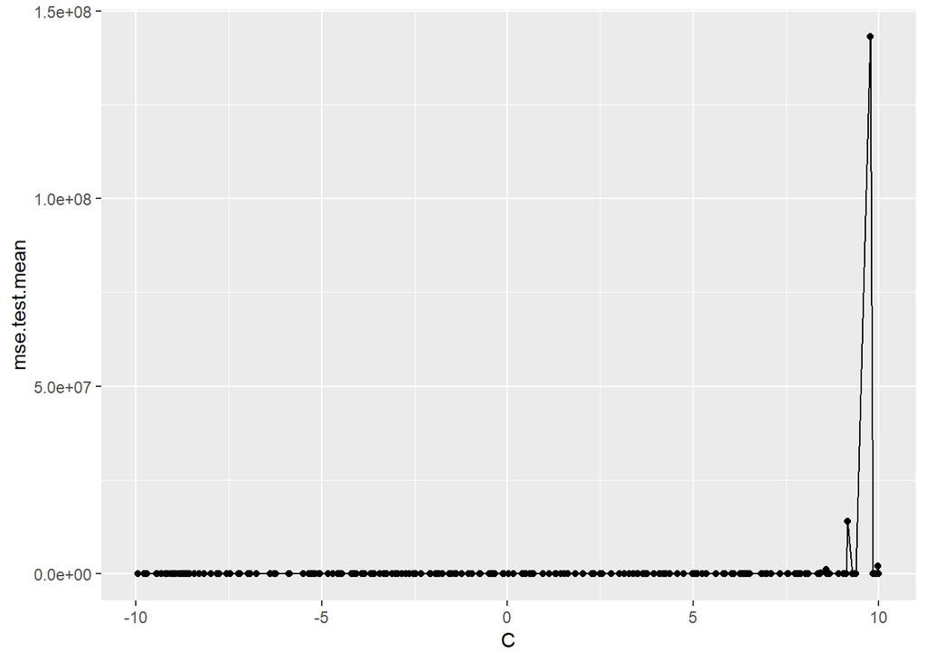

```r
plotHyperParsEffect(dataW, x = "C", y = "mse.test.mean",
                    plot.type = "line")
```

Zbiór `white_wines`.

## 3.3 Bonus - model-based optimization (aka Bayesian optimization)

```r
par.set = makeParamSet(
  makeNumericParam("C", -15, 15, trafo = function(x) 2^x),
  makeNumericParam("sigma", -15, 15, trafo = function(x) 2^x)
)

ctrl2 = makeMBOControl()
ctrl2 = setMBOControlTermination(ctrl2, iters = 5)
tune.ctrl = makeTuneControlMBO(mbo.control = ctrl2)
resMBO = tuneParams(makeLearner("regr.ksvm"), models_task, cv3, par.set = par.set, control = tune.ctrl,
  show.info = FALSE)
```

```r
print(resMBO)
```

```
## Tune result:
## Op. pars: C=3.24e+04; sigma=0.00176
## mse.test.mean=21395.5999946
```

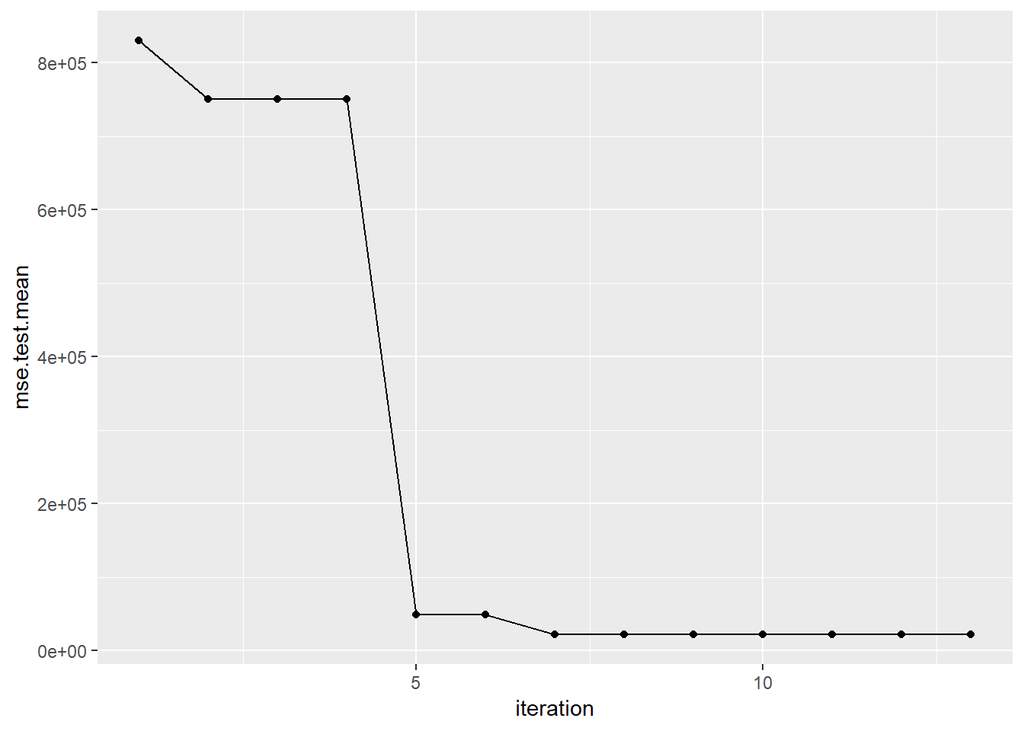

```r
dataMBO = generateHyperParsEffectData(resMBO)
plotHyperParsEffect(dataMBO, x = "iteration", y = "mse.test.mean",
                    plot.type = "line")
```

# 4 Wykresy PDP i porównanie z randomForest

Aby porównać modele przed strojeniem i po użyjemy wykresów `PDP` z wybraną zmienną, od której będzie zależała wartość przewidywana. W przypadku `Apartments` będzie to `construction.year`, a dla `white_wines` zmienna `V3`. Z modelami svm porównamy także algorytm `RandomForest`.

## 4.1 RandomForest

```r
# help
custom_predict <- function(object, newdata) {pred <- predict(object, newdata=newdata)
response <- pred$data$response
return(response)}

# random forest
# Apartments

set.seed(59)
apartments_rf_model <- randomForest(m2.price ~ ., data = apartments)
predicted_mi2_rf <- predict(apartments_rf_model, test)
mean((predicted_mi2_rf - test$m2.price)^2)
```

```
## [1] 82102.69
```

Wynik dla `Apartments`.

```r
# Wine

wine_rf_model <- randomForest(V1 ~ ., data = train_set_wine)
predicted_V1_rf <- predict(wine_rf_model, test_set)
mean((predicted_V1_rf - test_set$V1)^2)
```

```
## [1] 0.1731497
```

Wynik dla `White_wine`.

Las losowy poradził sobie gorzej od wystrojonego `SVM` dla danych `Apartments`, ale osiągnął lepsze wyniki od odpowiadającego modelu dla danych `White_wines`.

## 4.2 Wykresy PDP

```r
# Explainer

# apartments

explainer_svmA <- explain(regr_svm, data = dplyr::select(apartments, -m2.price),
                          y=apartments$m2.price, predict_function = custom_predict, label = "svmA")

explainer_svmA2 <- explain(regr_svmT, data = dplyr::select(apartments, -m2.price),
                           y=apartments$m2.price, predict_function = custom_predict, label = "svmAT")

explainer_rfA <- explain(apartments_rf_model,
                         data = apartmentsTest[,2:6], y = apartmentsTest$m2.price)

# wine

explainer_svmW <- explain(regr_svm2, data = dplyr::select(train_set_wine, -V1),
                          y=train_set_wine$V1, predict_function = custom_predict, label = "svmW")

explainer_svmWT <- explain(regr_svm2T, data = dplyr::select(train_set_wine, -V1),
                           y=train_set_wine$V1, predict_function = custom_predict, label = "svmWT")

explainer_rfW <- explain(wine_rf_model,
                         data = dplyr::select(train_set_wine, -V1), y=train_set_wine$V1)
```

```r
# PDP

#Apartments

sv_rf  <- single_variable(explainer_rfA, variable =  "construction.year", type = "pdp")
sv_svmA  <- single_variable(explainer_svmA, variable =  "construction.year", type = "pdp")
sv_svmA2  <- single_variable(explainer_svmA2, variable =  "construction.year", type = "pdp")
```

Wykresy dla `Apartments`.

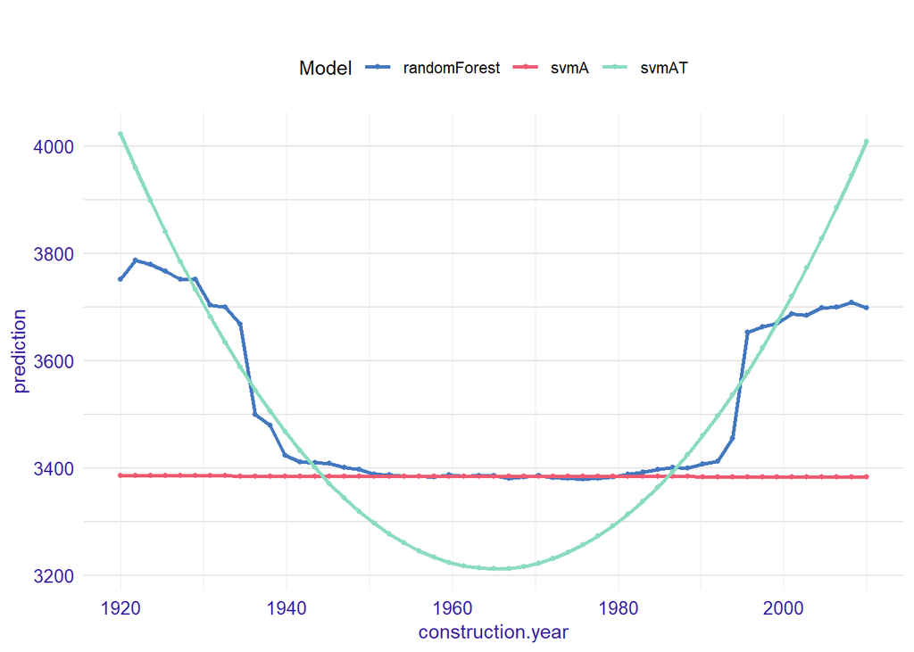

```r
plot(sv_rf,sv_svmA,sv_svmA2)
```

Jak widać na powayższym wykresie model `svmA`, czyli algorytm z domyślnymi parametrami całkowicie ignoruje zmienną `construction.year`. Model z dostrojonymi parametrami zachowuje się już całkowicie inaczej. Widać pewne podobieństwo do algorytmu lasów losowych, lecz model `svmAT` jest bardziej wygładzony i nie zawiera tak gwałtownych skoków.

Wykresy dla `White_wine`.

```r
# Wine

sv_rfW  <- single_variable(explainer_rfW, variable =  "V3", type = "pdp")
sv_svmW  <- single_variable(explainer_svmW, variable =  "V3", type = "pdp")
sv_svmW2  <- single_variable(explainer_svmWT, variable =  "V3", type = "pdp")
```

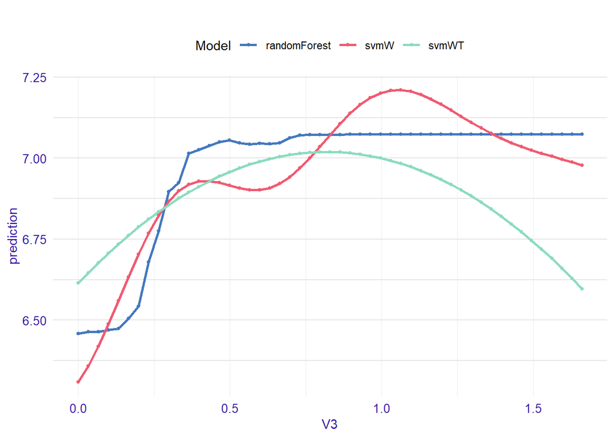

```r
plot(sv_rfW,sv_svmW,sv_svmW2)
```

Dla drugiego zbioru danych to niedostrojony `SVM` bardziej przypomina `randomForest`, ale algorytm z wybranymi parametrami nadal jest gładszy i kształt odpowiadającej linii na wykresie przypomina parabole tak jak poprzednim przypadku. Możliwe, że taki kształt wskazuje na brak problemu z `overfittingiem`, który wiąże się ze zbyt dużym dopasowaniem do danych treningowych i może być powodem dla gorszych wyników algorytmu drzew losowych w przypadku zbioru `apartments`.